# Table of Contents

## Import libs...

```python
import time
from datetime import datetime
import pandas as pd
import numpy as np
import collections
from sqlalchemy import create_engine

import xgboost as xgb
from xgboost import XGBClassifier
import sklearn
from sklearn.feature_selection import SelectFromModel
from sklearn.model_selection import GridSearchCV
from sklearn.ensemble import RandomForestClassifier
from sklearn.model_selection import train_test_split
from sklearn.metrics import accuracy_score
from sklearn.metrics import precision_score
from sklearn.metrics import recall_score
from sklearn.metrics import average_precision_score
import sklearn.metrics as metrics
import matplotlib.pyplot as plt

from imblearn.over_sampling import RandomOverSampler
from imblearn.over_sampling import SMOTE
from sklearn.model_selection import KFold
from sklearn.model_selection import cross_val_score
from sklearn.preprocessing import StandardScaler
from sklearn.pipeline import Pipeline
from sklearn.discriminant_analysis import LinearDiscriminantAnalysis

from sklearn.metrics import confusion_matrix
from sklearn.metrics import classification_report
from sklearn.metrics import make_scorer
from mlxtend.evaluate import lift_score
import pickle
from sklearn.externals import joblib

# msmote lib
from preprocessing import smote

%matplotlib inline
```

## Load data from tsv...

Note previous code versions acquired the data directly from an AWS RDS Postgres instance table. The table was exported as a tsv for future user convenience and accessibility.

```python
df = pd.DataFrame.from_csv('../data/acs_chem_lead_joined.tsv', sep='\t')
```

```python
df.shape
```

```
(8057, 769)
```

## Condition data in prep for modeling...

### Drop records with null in the lead_result_max_bucket

```python
df_cond = df.dropna(subset=['lead_result_max_bucket'])
```

```python
df_cond.shape
```

```
(1241, 769)
```

### Replace text values with numerical representations

```python
X = df_cond.replace(to_replace='(X)', value=1) \
      .replace('-',np.nan) \
      .replace('N',np.nan) \
      .replace('250,000+','250000') \
      .replace('3,500+','3500') \
      .replace('1,500+','1500') \
      .replace('4,000+','4000') \
      .replace('2,000,000+','2000000') \
      .replace('9.0+','9') \
      .replace('100-','100') \
      .fillna(0)
```

```python
X.shape
```

```
(1241, 769)
```

### Assign the selected feature name list (44)

```python
feature_names = [
	'est_sex_and_age_tot_pop',
	'est_sex_and_age_tot_pop_male',
	'est_sex_and_age_tot_pop_female',
	'est_sex_and_age_under_5_yrs',
	'est_sex_and_age_5_to_9_yrs',
	'est_sex_and_age_10_to_14_yrs',
	'est_sex_and_age_15_to_19_yrs',
	'est_sex_and_age_20_to_24_yrs',
	'est_sex_and_age_25_to_34_yrs',
	'est_sex_and_age_35_to_44_yrs',
	'est_sex_and_age_45_to_54_yrs',
	'est_sex_and_age_55_to_59_yrs',
	'est_sex_and_age_60_to_64_yrs',
	'est_sex_and_age_65_to_74_yrs',
	'est_sex_and_age_75_to_84_yrs',
	'est_sex_and_age_85_yrs_plus',
	'pct_yr_blt_units_built_2014_or_later',
	'pct_yr_blt_units_built_2010_to_2013',
	'pct_yr_blt_units_built_2000_to_2009',
	'pct_yr_blt_units_built_1990_to_1999',
	'pct_yr_blt_units_built_1980_to_1989',
	'pct_yr_blt_units_built_1970_to_1979',
	'pct_yr_blt_units_built_1960_to_1969',
	'pct_yr_blt_units_built_1950_to_1959',
	'pct_yr_blt_units_built_1940_to_1949',
	'pct_yr_blt_units_built_1939_or_earlier',
	'est_inc_tot_hshld_mean_household_inc_dol',
	'est_units_in_struct',
	'est_inc_tot_hshld_median_household_inc_dol',
	'pct_emp_pop_16_yrs_plus_in_labor_force_civ_emp',
	'est_disability_tot_disabled',
	'est_year_householder_moved_into_unit_occ_unts_2015_or_later',
	'est_year_householder_moved_into_unit_occ_unts_2010_to_2014',
	'est_year_householder_moved_into_unit_occ_unts_2000_to_2009',
	'est_year_householder_moved_into_unit_occ_unts_1990_to_1999',
	'est_year_householder_moved_into_unit_occ_unts_1980_to_1989',
	'est_year_householder_moved_into_unit_occ_unts_1979prior',
	'pct_thr_00650',
	'pct_thr_00660',
	'pct_thr_01051',
	'pct_thr_32102',
	'pct_thr_34418',
	'pct_thr_34423',
	'pct_thr_39175',
]
```

### Assign the all feature name list minus the lead predictor fields (757)

```python
feature_names_all = [
	'est_occ_tot_housing_units',
	'pct_occ_tot_housing_units',
	'est_occ_tot_housing_units_occ_unts',
	'pct_occ_tot_housing_units_occ_unts',
	'est_occ_tot_housing_units_vac_housing_units',
	'pct_occ_tot_housing_units_vac_housing_units',
	'est_occ_homeowner_vac_rate',
	'pct_occ_homeowner_vac_rate',
	'est_occ_rental_vac_rate',
	'pct_occ_rental_vac_rate',
	'est_units_in_struct',
	'pct_units_in_struct',
	'est_units_in_struct_1_unit_detached',
	'pct_units_in_struct_1_unit_detached',
	'est_units_in_struct_1_unit_attached',
	'pct_units_in_struct_1_unit_attached',
	'est_units_in_struct_2_units',
	'pct_units_in_struct_2_units',
	'est_units_in_struct_3_or_4_units',
	'pct_units_in_struct_3_or_4_units',
	'est_units_in_struct_5_to_9_units',
	'pct_units_in_struct_5_to_9_units',
	'est_units_in_struct_10_to_19_units',
	'pct_units_in_struct_10_to_19_units',
	'est_units_in_struct_20_or_more_units',
	'pct_units_in_struct_20_or_more_units',
	'est_units_in_struct_mobile_home',
	'pct_units_in_struct_mobile_home',
	'est_units_in_struct_boat_rv_van_etc',
	'pct_units_in_struct_boat_rv_van_etc',
	'est_yr_blt_units',
	'pct_yr_blt_units',
	'est_yr_blt_units_built_2014_or_later',
	'pct_yr_blt_units_built_2014_or_later',
	'est_yr_blt_units_built_2010_to_2013',
	'pct_yr_blt_units_built_2010_to_2013',
	'est_yr_blt_units_built_2000_to_2009',
	'pct_yr_blt_units_built_2000_to_2009',
	'est_yr_blt_units_built_1990_to_1999',
	'pct_yr_blt_units_built_1990_to_1999',
	'est_yr_blt_units_built_1980_to_1989',
	'pct_yr_blt_units_built_1980_to_1989',
	'est_yr_blt_units_built_1970_to_1979',
	'pct_yr_blt_units_built_1970_to_1979',
	'est_yr_blt_units_built_1960_to_1969',
	'pct_yr_blt_units_built_1960_to_1969',
	'est_yr_blt_units_built_1950_to_1959',
	'pct_yr_blt_units_built_1950_to_1959',
	'est_yr_blt_units_built_1940_to_1949',
	'pct_yr_blt_units_built_1940_to_1949',
	'est_yr_blt_units_built_1939_or_earlier',
	'pct_yr_blt_units_built_1939_or_earlier',
	'est_rooms_units',
	'pct_rooms_units',
	'est_rooms_units_1_room',
	'pct_rooms_units_1_room',
	'est_rooms_units_2_rooms',
	'pct_rooms_units_2_rooms',
	'est_rooms_units_3_rooms',
	'pct_rooms_units_3_rooms',
	'est_rooms_units_4_rooms',
	'pct_rooms_units_4_rooms',
	'est_rooms_units_5_rooms',
	'pct_rooms_units_5_rooms',
	'est_rooms_units_6_rooms',
	'pct_rooms_units_6_rooms',
	'est_rooms_units_7_rooms',
	'pct_rooms_units_7_rooms',
	'est_rooms_units_8_rooms',
	'pct_rooms_units_8_rooms',
	'est_rooms_units_9_rooms_or_more',
	'pct_rooms_units_9_rooms_or_more',
	'est_rooms_units_median_rooms',
	'pct_rooms_units_median_rooms',
	'est_bedrooms_units',
	'pct_bedrooms_units',
	'est_bedrooms_units_no_bedroom',
	'pct_bedrooms_units_no_bedroom',
	'est_bedrooms_units_1_bedroom',
	'pct_bedrooms_units_1_bedroom',
	'est_bedrooms_units_2_bedrooms',
	'pct_bedrooms_units_2_bedrooms',
	'est_bedrooms_units_3_bedrooms',
	'pct_bedrooms_units_3_bedrooms',
	'est_bedrooms_units_4_bedrooms',
	'pct_bedrooms_units_4_bedrooms',
	'est_bedrooms_units_5_or_more_bedrooms',
	'pct_bedrooms_units_5_or_more_bedrooms',
	'est_housing_tenure_occ_unts',
	'pct_housing_tenure_occ_unts',
	'est_housing_tenure_occ_unts_owner_occupied',
	'pct_housing_tenure_occ_unts_owner_occupied',
	'est_housing_tenure_occ_unts_renter_occupied',
	'pct_housing_tenure_occ_unts_renter_occupied',
	'est_housing_tenure_avg_houshld_of_owner_occupied_unit',
	'pct_housing_tenure_avg_houshld_of_owner_occupied_unit',
	'est_housing_tenure_avg_houshld_of_renter_occupied_unit',
	'pct_housing_tenure_avg_houshld_of_renter_occupied_unit',
	'est_year_householder_moved_into_unit_occ_unts',
	'pct_year_householder_moved_into_unit_occ_unts',
	'est_year_householder_moved_into_unit_occ_unts_2015_or_later',
	'pct_year_householder_moved_into_unit_occ_unts_2015_or_later',
	'est_year_householder_moved_into_unit_occ_unts_2010_to_2014',
	'pct_year_householder_moved_into_unit_occ_unts_2010_to_2014',
	'est_year_householder_moved_into_unit_occ_unts_2000_to_2009',
	'pct_year_householder_moved_into_unit_occ_unts_2000_to_2009',
	'est_year_householder_moved_into_unit_occ_unts_1990_to_1999',
	'pct_year_householder_moved_into_unit_occ_unts_1990_to_1999',
	'est_year_householder_moved_into_unit_occ_unts_1980_to_1989',
	'pct_year_householder_moved_into_unit_occ_unts_1980_to_1989',
	'est_year_householder_moved_into_unit_occ_unts_1979prior',
	'pct_year_householder_moved_into_unit_occ_unts_1979prior',
	'est_vehicles_occ_unts',
	'pct_vehicles_occ_unts',
	'est_vehicles_occ_unts_no_vehicles',
	'pct_vehicles_occ_unts_no_vehicles',
	'est_vehicles_occ_unts_1_vehicles',
	'pct_vehicles_occ_unts_1_vehicles',
	'est_vehicles_occ_unts_2_vehicles',
	'pct_vehicles_occ_unts_2_vehicles',
	'est_vehicles_occ_unts_3_or_more_vehicles',
	'pct_vehicles_occ_unts_3_or_more_vehicles',
	'est_house_heating_fuel_occ_unts',
	'pct_house_heating_fuel_occ_unts',
	'est_house_heating_fuel_occ_unts_utility_gas',
	'pct_house_heating_fuel_occ_unts_utility_gas',
	'est_house_heating_fuel_occ_unts_bottled_tank_or_lp_gas',
	'pct_house_heating_fuel_occ_unts_bottled_tank_or_lp_gas',
	'est_house_heating_fuel_occ_unts_electricity',
	'pct_house_heating_fuel_occ_unts_electricity',
	'est_house_heating_fuel_occ_unts_fuel_oil_kerosene_etc',
	'pct_house_heating_fuel_occ_unts_fuel_oil_kerosene_etc',
	'est_house_heating_fuel_occ_unts_coal_or_coke',
	'pct_house_heating_fuel_occ_unts_coal_or_coke',
	'est_house_heating_fuel_occ_unts_wood',
	'pct_house_heating_fuel_occ_unts_wood',
	'est_house_heating_fuel_occ_unts_solar_energy',
	'pct_house_heating_fuel_occ_unts_solar_energy',
	'est_house_heating_fuel_occ_unts_other_fuel',
	'pct_house_heating_fuel_occ_unts_other_fuel',
	'est_house_heating_fuel_occ_unts_no_fuel_used',
	'pct_house_heating_fuel_occ_unts_no_fuel_used',
	'est_selected_char_occ_unts',
	'pct_selected_char_occ_unts',
	'est_selected_char_occ_unts_lacking_plumbing_fac',
	'pct_selected_char_occ_unts_lacking_plumbing_fac',
	'est_selected_char_occ_unts_lacking_kitchen_fac',
	'pct_selected_char_occ_unts_lacking_kitchen_fac',
	'est_selected_char_occ_unts_no_teleph',
	'pct_selected_char_occ_unts_no_teleph',
	'est_occupants_per_room_occ_unts',
	'pct_occupants_per_room_occ_unts',
	'est_occupants_per_room_occ_unts_100_or_less',
	'pct_occupants_per_room_occ_unts_100_or_less',
	'est_occupants_per_room_occ_unts_101_to_150',
	'pct_occupants_per_room_occ_unts_101_to_150',
	'est_occupants_per_room_occ_unts_151_or_more',
	'pct_occupants_per_room_occ_unts_151_or_more',
	'est_value_own_occ',
	'pct_value_own_occ',
	'est_value_own_occ_less_than_50000',
	'pct_value_own_occ_less_than_50000',
	'est_value_own_occ_50000_to_99999',
	'pct_value_own_occ_50000_to_99999',
	'est_value_own_occ_100000_to_149999',
	'pct_value_own_occ_100000_to_149999',
	'est_value_own_occ_150000_to_199999',
	'pct_value_own_occ_150000_to_199999',
	'est_value_own_occ_200000_to_299999',
	'pct_value_own_occ_200000_to_299999',
	'est_value_own_occ_300000_to_499999',
	'pct_value_own_occ_300000_to_499999',
	'est_value_own_occ_500000_to_999999',
	'pct_value_own_occ_500000_to_999999',
	'est_value_own_occ_1000000_or_more',
	'pct_value_own_occ_1000000_or_more',
	'est_value_own_occ_median_dollars',
	'pct_value_own_occ_median_dollars',
	'est_mortgage_status_own_occ',
	'pct_mortgage_status_own_occ',
	'est_mortgage_status_own_occ_unit_with_mort',
	'pct_mortgage_status_own_occ_unit_with_mort',
	'est_mortgage_status_own_occ_unit_without_mort',
	'pct_mortgage_status_own_occ_unit_without_mort',
	'est_month_ownr_cst_smoc_unit_with_mort',
	'pct_month_ownr_cst_smoc_unit_with_mort',
	'est_month_ownr_cst_smoc_unit_with_mort_less_than_500',
	'pct_month_ownr_cst_smoc_unit_with_mort_less_than_500',
	'est_month_ownr_cst_smoc_unit_with_mort_500_to_999',
	'pct_month_ownr_cst_smoc_unit_with_mort_500_to_999',
	'est_month_ownr_cst_smoc_unit_with_mort_1000_to_1499',
	'pct_month_ownr_cst_smoc_unit_with_mort_1000_to_1499',
	'est_month_ownr_cst_smoc_unit_with_mort_1500_to_1999',
	'pct_month_ownr_cst_smoc_unit_with_mort_1500_to_1999',
	'est_month_ownr_cst_smoc_unit_with_mort_2000_to_2499',
	'pct_month_ownr_cst_smoc_unit_with_mort_2000_to_2499',
	'est_month_ownr_cst_smoc_unit_with_mort_2500_to_2999',
	'pct_month_ownr_cst_smoc_unit_with_mort_2500_to_2999',
	'est_month_ownr_cst_smoc_unit_with_mort_3000_or_more',
	'pct_month_ownr_cst_smoc_unit_with_mort_3000_or_more',
	'est_month_ownr_cst_smoc_unit_with_mort_median_dollars',
	'pct_month_ownr_cst_smoc_unit_with_mort_median_dollars',
	'est_month_ownr_cst_smoc_unit_without_mort',
	'pct_month_ownr_cst_smoc_unit_without_mort',
	'est_month_ownr_cst_smoc_unit_without_mort_less_than_250',
	'pct_month_ownr_cst_smoc_unit_without_mort_less_than_250',
	'est_month_ownr_cst_smoc_unit_without_mort_250_to_399',
	'pct_month_ownr_cst_smoc_unit_without_mort_250_to_399',
	'est_month_ownr_cst_smoc_unit_without_mort_400_to_599',
	'pct_month_ownr_cst_smoc_unit_without_mort_400_to_599',
	'est_month_ownr_cst_smoc_unit_without_mort_600_to_799',
	'pct_month_ownr_cst_smoc_unit_without_mort_600_to_799',
	'est_month_ownr_cst_smoc_unit_without_mort_800_to_999',
	'pct_month_ownr_cst_smoc_unit_without_mort_800_to_999',
	'est_month_ownr_cst_smoc_unit_without_mort_1000_or_more',
	'pct_month_ownr_cst_smoc_unit_without_mort_1000_or_more',
	'est_month_ownr_cst_smoc_unit_without_mort_median_dollars',
	'pct_month_ownr_cst_smoc_unit_without_mort_median_dollars',
	'est_smocapi_unit_with_mort',
	'pct_smocapi_unit_with_mort',
	'est_smocapi_unit_with_mort_less_than_200_pct',
	'pct_smocapi_unit_with_mort_less_than_200_pct',
	'est_smocapi_unit_with_mort_200_to_249_pct',
	'pct_smocapi_unit_with_mort_200_to_249_pct',
	'est_smocapi_unit_with_mort_250_to_299_pct',
	'pct_smocapi_unit_with_mort_250_to_299_pct',
	'est_smocapi_unit_with_mort_300_to_349_pct',
	'pct_smocapi_unit_with_mort_300_to_349_pct',
	'est_smocapi_unit_with_mort_350_pct_or_more',
	'pct_smocapi_unit_with_mort_350_pct_or_more',
	'est_smocapi_unit_nomortg',
	'pct_smocapi_unit_nomortg',
	'est_smocapi_unit_nomortg_less_than_100_pct',
	'pct_smocapi_unit_nomortg_less_than_100_pct',
	'est_smocapi_unit_nomortg_100_to_149_pct',
	'pct_smocapi_unit_nomortg_100_to_149_pct',
	'est_smocapi_unit_nomortg_150_to_199_pct',
	'pct_smocapi_unit_nomortg_150_to_199_pct',
	'est_smocapi_unit_nomortg_200_to_249_pct',
	'pct_smocapi_unit_nomortg_200_to_249_pct',
	'est_smocapi_unit_nomortg_250_to_299_pct',
	'pct_smocapi_unit_nomortg_250_to_299_pct',
	'est_smocapi_unit_nomortg_300_to_349_pct',
	'pct_smocapi_unit_nomortg_300_to_349_pct',
	'est_smocapi_unit_nomortg_350_pct_or_more',
	'pct_smocapi_unit_nomortg_350_pct_or_more',
	'est_gross_rent_occ_unt_paying_rnt',
	'pct_gross_rent_occ_unt_paying_rnt',
	'est_gross_rent_occ_unt_paying_rnt_less_than_500',
	'pct_gross_rent_occ_unt_paying_rnt_less_than_500',
	'est_gross_rent_occ_unt_paying_rnt_500_to_999',
	'pct_gross_rent_occ_unt_paying_rnt_500_to_999',
	'est_gross_rent_occ_unt_paying_rnt_1000_to_1499',
	'pct_gross_rent_occ_unt_paying_rnt_1000_to_1499',
	'est_gross_rent_occ_unt_paying_rnt_1500_to_1999',
	'pct_gross_rent_occ_unt_paying_rnt_1500_to_1999',
	'est_gross_rent_occ_unt_paying_rnt_2000_to_2499',
	'pct_gross_rent_occ_unt_paying_rnt_2000_to_2499',
	'est_gross_rent_occ_unt_paying_rnt_2500_to_2999',
	'pct_gross_rent_occ_unt_paying_rnt_2500_to_2999',
	'est_gross_rent_occ_unt_paying_rnt_3000_or_more',
	'pct_gross_rent_occ_unt_paying_rnt_3000_or_more',
	'est_gross_rent_occ_unt_paying_rnt_median_dollars',
	'pct_gross_rent_occ_unt_paying_rnt_median_dollars',
	'est_gross_rent_no_rent_paid',
	'pct_gross_rent_no_rent_paid',
	'est_grapi_occ_unt_paying_rnt_excl',
	'pct_grapi_occ_unt_paying_rnt_excl',
	'est_grapi_occ_unt_paying_rnt_excl_less_than_150_pct',
	'pct_grapi_occ_unt_paying_rnt_excl_less_than_150_pct',
	'est_grapi_occ_unt_paying_rnt_excl_150_to_199_pct',
	'pct_grapi_occ_unt_paying_rnt_excl_150_to_199_pct',
	'est_grapi_occ_unt_paying_rnt_excl_200_to_249_pct',
	'pct_grapi_occ_unt_paying_rnt_excl_200_to_249_pct',
	'est_grapi_occ_unt_paying_rnt_excl_250_to_299_pct',
	'pct_grapi_occ_unt_paying_rnt_excl_250_to_299_pct',
	'est_grapi_occ_unt_paying_rnt_excl_300_to_349_pct',
```

```python
	'pct_grapi_occ_unt_paying_rnt_excl_300_to_349_pct',
	'est_grapi_occ_unt_paying_rnt_excl_350_pct_or_more',
	'pct_grapi_occ_unt_paying_rnt_excl_350_pct_or_more',
	'est_grapi_not_computed',
	'pct_grapi_not_computed',
	'est_hshld_tot_hshld',
	'pct_hshld_tot_hshld',
	'est_hshld_tot_fam',
	'pct_hshld_tot_fam',
	'est_hshld_tot_fam_w_child_u18_yrs',
	'pct_hshld_tot_fam_w_child_u18_yrs',
	'est_hshld_tot_fam_married_couple_family',
	'pct_hshld_tot_fam_married_couple_family',
	'est_hshld_tot_fam_married_couple_family_w_child_u18_yrs',
	'pct_hshld_tot_fam_married_couple_family_w_child_u18_yrs',
	'est_hshld_tot_fam_male_sngl',
	'pct_hshld_tot_fam_male_sngl',
	'est_hshld_tot_fam_male_sngl_w_child_u18_yrs',
	'pct_hshld_tot_fam_male_sngl_w_child_u18_yrs',
	'est_hshld_tot_fam_fem_sngl',
	'pct_hshld_tot_fam_fem_sngl',
	'est_hshld_tot_fam_fem_sngl_w_child_u18_yrs',
	'pct_hshld_tot_fam_fem_sngl_w_child_u18_yrs',
	'est_hshld_tot_hshld_nonfamily_hshld',
	'pct_hshld_tot_hshld_nonfamily_hshld',
	'est_hshld_tot_alone',
	'pct_hshld_tot_alone',
	'est_hshld_tot_alone_65_yrs_plus',
	'pct_hshld_tot_alone_65_yrs_plus',
	'est_hshld_hshld_w_u18_yrs',
	'pct_hshld_hshld_w_u18_yrs',
	'est_hshld_hshld_w_65_yrs_plus',
	'pct_hshld_hshld_w_65_yrs_plus',
	'est_hshld_average_household_size',
	'pct_hshld_average_household_size',
	'est_hshld_average_family_size',
	'pct_hshld_average_family_size',
	'est_relationship_pop_in_hshld',
	'pct_relationship_pop_in_hshld',
	'est_relationship_pop_in_hshld_householder',
	'pct_relationship_pop_in_hshld_householder',
	'est_relationship_pop_in_hshld_spouse',
	'pct_relationship_pop_in_hshld_spouse',
	'est_relationship_pop_in_hshld_child',
	'pct_relationship_pop_in_hshld_child',
	'est_relationship_pop_in_hshld_other_rel',
	'pct_relationship_pop_in_hshld_other_rel',
	'est_relationship_pop_in_hshld_nonrel',
	'pct_relationship_pop_in_hshld_nonrel',
	'est_relationship_pop_in_hshld_nonrel_unmarr_partner',
	'pct_relationship_pop_in_hshld_nonrel_unmarr_partner',
	'est_fert_15_to_50_yrs_birth',
	'pct_fert_15_to_50_yrs_birth',
	'est_fert_15_to_50_yrs_birth_unmarr',
	'pct_fert_15_to_50_yrs_birth_unmarr',
	'est_fert_15_to_50_yrs_birth_unmarr_per_1000_unmarr_women',
	'pct_fert_15_to_50_yrs_birth_unmarr_per_1000_unmarr_women',
	'est_fert_15_to_50_yrs_birth_per_1000_women_15_to_50_yrs',
	'pct_fert_15_to_50_yrs_birth_per_1000_women_15_to_50_yrs',
	'est_fert_15_to_50_yrs_birth_per_1000_women_15_to_19_yrs',
	'pct_fert_15_to_50_yrs_birth_per_1000_women_15_to_19_yrs',
	'est_fert_15_to_50_yrs_birth_per_1000_women_20_to_34_yrs',
	'pct_fert_15_to_50_yrs_birth_per_1000_women_20_to_34_yrs',
	'est_fert_15_to_50_yrs_birth_per_1000_women_35_to_50_yrs',
	'pct_fert_15_to_50_yrs_birth_per_1000_women_35_to_50_yrs',
	'est_school_enroll_pop_3_yrs_plus_',
	'pct_school_enroll_pop_3_yrs_plus_',
	'est_school_enroll_pop_3_yrs_plus_nursery_school_preschool',
	'pct_school_enroll_pop_3_yrs_plus_nursery_school_preschool',
	'est_school_enroll_pop_3_yrs_plus_kindergarten',
	'pct_school_enroll_pop_3_yrs_plus_kindergarten',
	'est_school_enroll_pop_3_yrs_plus_elem_gr_1_8',
	'pct_school_enroll_pop_3_yrs_plus_elem_gr_1_8',
	'est_school_enroll_pop_3_yrs_plus_high_school_gr_9_12',
	'pct_school_enroll_pop_3_yrs_plus_high_school_gr_9_12',
	'est_school_enroll_pop_3_yrs_plus_college_or_graduate_school',
	'pct_school_enroll_pop_3_yrs_plus_college_or_graduate_school',
	'est_educ_pop_25_yrs_plus',
	'pct_educ_pop_25_yrs_plus',
	'est_educ_pop_25_yrs_plus_less_9th_grade',
	'pct_educ_pop_25_yrs_plus_less_9th_grade',
	'est_educ_pop_25_yrs_plus_9th_to_12th_grade_no_diploma',
	'pct_educ_pop_25_yrs_plus_9th_to_12th_grade_no_diploma',
	'est_educ_pop_25_yrs_plus_hs',
	'pct_educ_pop_25_yrs_plus_hs',
	'est_educ_pop_25_yrs_plus_some_college_no_degree',
	'pct_educ_pop_25_yrs_plus_some_college_no_degree',
	'est_educ_pop_25_yrs_plus_associates_degree',
	'pct_educ_pop_25_yrs_plus_associates_degree',
	'est_educ_pop_25_yrs_plus_bachelors_degree',
	'pct_educ_pop_25_yrs_plus_bachelors_degree',
	'est_educ_pop_25_yrs_plus_graduate_or_professional_degree',
	'pct_educ_pop_25_yrs_plus_graduate_or_professional_degree',
	'est_educ_pct_high_school_graduate_or_higher',
	'pct_educ_pct_high_school_graduate_or_higher',
	'est_educ_pct_bachelors_degree_or_higher',
	'pct_educ_pct_bachelors_degree_or_higher',
	'est_disability_tot_civilian_noninstitutionalized_pop',
	'pct_disability_tot_civilian_noninstitutionalized_pop',
	'est_disability_tot_disabled',
	'pct_disability_tot_disabled',
	'est_disability_u18_yrs',
	'pct_disability_u18_yrs',
	'est_disability_u18_yrs_with_a_disability',
	'pct_disability_u18_yrs_with_a_disability',
	'est_disability_18_to_64_yrs',
	'pct_disability_18_to_64_yrs',
	'est_disability_18_to_64_yrs_with_a_disability',
	'pct_disability_18_to_64_yrs_with_a_disability',
	'est_disability_65_yrs_plus',
	'pct_disability_65_yrs_plus',
	'est_disability_65_yrs_plus_with_a_disability',
	'pct_disability_65_yrs_plus_with_a_disability',
	'est_res_pop_1_yr_plus',
	'pct_res_pop_1_yr_plus',
	'est_res_pop_1_yr_plus_same_house',
	'pct_res_pop_1_yr_plus_same_house',
	'est_res_pop_1_yr_plus_diff_house_in_the_us',
	'pct_res_pop_1_yr_plus_diff_house_in_the_us',
	'est_res_pop_1_yr_plus_diff_house_in_the_us_same_county',
	'pct_res_pop_1_yr_plus_diff_house_in_the_us_same_county',
	'est_res_pop_1_yr_plus_diff_house_diff_county',
	'pct_res_pop_1_yr_plus_diff_house_diff_county',
	'est_res_pop_1_yr_plus_diff_house_diff_county_same_state',
	'pct_res_pop_1_yr_plus_diff_house_diff_county_same_state',
	'est_res_pop_1_yr_plus_diff_house_diff_county_diff_state',
	'pct_res_pop_1_yr_plus_diff_house_diff_county_diff_state',
	'est_res_pop_1_yr_plus_abroad',
	'pct_res_pop_1_yr_plus_abroad',
	'est_birth_tot_pop',
	'pct_birth_tot_pop',
	'est_birth_tot_pop_nat',
	'pct_birth_tot_pop_nat',
	'est_birth_tot_pop_nat_us',
	'pct_birth_tot_pop_nat_us',
	'est_birth_tot_pop_nat_us_state_of_res',
	'pct_birth_tot_pop_nat_us_state_of_res',
	'est_birth_tot_pop_nat_us_diff_state',
	'pct_birth_tot_pop_nat_us_diff_state',
	'est_birth_tot_pop_nat_abrd',
	'pct_birth_tot_pop_nat_abrd',
	'est_birth_tot_pop_foreign_born',
	'pct_birth_tot_pop_foreign_born',
	'est_us_cit_status_foreign_born_pop',
	'pct_us_cit_status_foreign_born_pop',
	'est_us_cit_status_foreign_born_pop_naturalized_us_citizen',
	'pct_us_cit_status_foreign_born_pop_naturalized_us_citizen',
	'est_us_cit_status_foreign_born_pop_not_a_us_citizen',
	'pct_us_cit_status_foreign_born_pop_not_a_us_citizen',
	'est_yr_of_entry_pop_born_outside_the_united_states',
	'pct_yr_of_entry_pop_born_outside_the_united_states',
	'est_yr_of_entry_nat',
	'pct_yr_of_entry_nat',
	'est_yr_of_entry_nat_entered_2010_or_later',
	'pct_yr_of_entry_nat_entered_2010_or_later',
	'est_yr_of_entry_nat_entered_before_2010',
	'pct_yr_of_entry_nat_entered_before_2010',
	'est_yr_of_entry_foreign_born',
	'pct_yr_of_entry_foreign_born',
	'est_yr_of_entry_foreign_born_entered_2010_or_later',
	'pct_yr_of_entry_foreign_born_entered_2010_or_later',
	'est_yr_of_entry_foreign_born_entered_before_2010',
	'pct_yr_of_entry_foreign_born_entered_before_2010',
	'est_computer_tot_hshld',
	'pct_computer_tot_hshld',
	'est_computer_tot_hshld_with_a_computer',
	'pct_computer_tot_hshld_with_a_computer',
	'est_computer_tot_hshld_broadband',
	'pct_computer_tot_hshld_broadband',
	'est_emp_pop_16_yrs_plus',
	'pct_emp_pop_16_yrs_plus',
	'est_emp_pop_16_yrs_plus_in_labor_force',
	'pct_emp_pop_16_yrs_plus_in_labor_force',
	'est_emp_pop_16_yrs_plus_in_labor_force_civ',
	'pct_emp_pop_16_yrs_plus_in_labor_force_civ',
	'est_emp_pop_16_yrs_plus_in_labor_force_civ_emp',
	'pct_emp_pop_16_yrs_plus_in_labor_force_civ_emp',
	'est_emp_pop_16_yrs_plus_in_labor_force_civ_unemp',
	'pct_emp_pop_16_yrs_plus_in_labor_force_civ_unemp',
	'est_emp_pop_16_yrs_plus_in_labor_force_armed_forces',
	'pct_emp_pop_16_yrs_plus_in_labor_force_armed_forces',
	'est_emp_pop_16_yrs_plus_not_in_labor_force',
	'pct_emp_pop_16_yrs_plus_not_in_labor_force',
	'est_emp_civ',
	'pct_emp_civ',
	'est_emp_civ_unemployment_rate',
	'pct_emp_civ_unemployment_rate',
	'est_emp_fems_16_yrs_plus',
	'pct_emp_fems_16_yrs_plus',
	'est_emp_fems_16_yrs_plus_in_labor_force',
	'pct_emp_fems_16_yrs_plus_in_labor_force',
	'est_emp_fems_16_yrs_plus_in_labor_force_civ',
	'pct_emp_fems_16_yrs_plus_in_labor_force_civ',
	'est_emp_fems_16_yrs_plus_in_labor_force_civ_emp',
	'pct_emp_fems_16_yrs_plus_in_labor_force_civ_emp',
	'est_emp_child_u6_yrs',
	'pct_emp_child_u6_yrs',
	'est_emp_child_u6_yrs_all_parents_in_fam_in_labor_force',
	'pct_emp_child_u6_yrs_all_parents_in_fam_in_labor_force',
	'est_emp_child_6_to_17_yrs',
	'pct_emp_child_6_to_17_yrs',
	'est_emp_child_6_to_17_yrs_all_parents_in_fam_in_labor_force',
	'pct_emp_child_6_to_17_yrs_all_parents_in_fam_in_labor_force',
	'est_inc_tot_hshld',
	'pct_inc_tot_hshld',
	'est_inc_tot_hshld_less_than_10000',
	'pct_inc_tot_hshld_less_than_10000',
	'est_inc_tot_hshld_10000_to_14999',
	'pct_inc_tot_hshld_10000_to_14999',
	'est_inc_tot_hshld_15000_to_24999',
	'pct_inc_tot_hshld_15000_to_24999',
	'est_inc_tot_hshld_25000_to_34999',
	'pct_inc_tot_hshld_25000_to_34999',
	'est_inc_tot_hshld_35000_to_49999',
	'pct_inc_tot_hshld_35000_to_49999',
	'est_inc_tot_hshld_50000_to_74999',
	'pct_inc_tot_hshld_50000_to_74999',
	'est_inc_tot_hshld_75000_to_99999',
	'pct_inc_tot_hshld_75000_to_99999',
	'est_inc_tot_hshld_100000_to_149999',
	'pct_inc_tot_hshld_100000_to_149999',
	'est_inc_tot_hshld_150000_to_199999',
	'pct_inc_tot_hshld_150000_to_199999',
	'est_inc_tot_hshld_200000_or_more',
	'pct_inc_tot_hshld_200000_or_more',
	'est_inc_tot_hshld_median_household_inc_dol',
	'pct_inc_tot_hshld_median_household_inc_dol',
	'est_inc_tot_hshld_mean_household_inc_dol',
	'pct_inc_tot_hshld_mean_household_inc_dol',
	'est_inc_with_earnings',
	'pct_inc_with_earnings',
	'est_inc_with_earnings_mean_earnings_dol',
	'pct_inc_with_earnings_mean_earnings_dol',
	'est_inc_with_soc_sec',
	'pct_inc_with_soc_sec',
	'est_inc_with_soc_sec_mean_soc_sec_inc_dol',
	'pct_inc_with_soc_sec_mean_soc_sec_inc_dol',
	'est_inc_with_retirement_inc',
	'pct_inc_with_retirement_inc',
	'est_inc_with_retirement_inc_mean_retirement_inc_dol',
	'pct_inc_with_retirement_inc_mean_retirement_inc_dol',
	'est_inc_with_supp_inc',
	'pct_inc_with_supp_inc',
	'est_inc_with_supp_inc_mean_supp_inc_dol',
	'pct_inc_with_supp_inc_mean_supp_inc_dol',
	'est_inc_with_cash_pub_ast_inc',
	'pct_inc_with_cash_pub_ast_inc',
	'est_inc_with_cash_pub_ast_inc_mean_cash_pub_ast_inc_dol',
	'pct_inc_with_cash_pub_ast_inc_mean_cash_pub_ast_inc_dol',
	'est_inc_with_food_stamp',
	'pct_inc_with_food_stamp',
	'est_inc_fam',
	'pct_inc_fam',
	'est_inc_fam_less_than_10000',
	'pct_inc_fam_less_than_10000',
	'est_inc_fam_10000_to_14999',
	'pct_inc_fam_10000_to_14999',
	'est_inc_fam_15000_to_24999',
	'pct_inc_fam_15000_to_24999',
	'est_inc_fam_25000_to_34999',
	'pct_inc_fam_25000_to_34999',
	'est_inc_fam_35000_to_49999',
	'pct_inc_fam_35000_to_49999',
	'est_inc_fam_50000_to_74999',
	'pct_inc_fam_50000_to_74999',
	'est_inc_fam_75000_to_99999',
	'pct_inc_fam_75000_to_99999',
	'est_inc_fam_100000_to_149999',
	'pct_inc_fam_100000_to_149999',
	'est_inc_fam_150000_to_199999',
	'pct_inc_fam_150000_to_199999',
	'est_inc_fam_200000_or_more',
	'pct_inc_fam_200000_or_more',
	'est_inc_fam_median_fam_inc_dol',
	'pct_inc_fam_median_fam_inc_dol',
	'est_inc_fam_mean_fam_inc_dol',
	'pct_inc_fam_mean_fam_inc_dol',
	'est_inc_per_capita_inc_dol',
	'pct_inc_per_capita_inc_dol',
	'est_inc_nonfam_hshld',
	'pct_inc_nonfam_hshld',
	'est_inc_nonfam_hshld_median_nonfam_inc_dol',
	'pct_inc_nonfam_hshld_median_nonfam_inc_dol',
	'est_inc_nonfam_hshld_mean_nonfam_inc_dol',
	'pct_inc_nonfam_hshld_mean_nonfam_inc_dol',
	'est_inc_median_earnings_for_workers_dol',
	'pct_inc_median_earnings_for_workers_dol',
	'est_inc_median_earnings_for_male_full_time_ann_workers_dol',
	'pct_inc_median_earnings_for_male_full_time_ann_workers_dol',
	'est_inc_median_earnings_for_fem_full_time_ann_workers_dol',
	'pct_inc_median_earnings_for_fem_full_time_ann_workers_dol',
	'est_pct_of_fam_pov_all_fam',
```

```python
	'pct_pct_of_fam_pov_all_fam',
	'est_pct_of_fam_pov_all_fam_child_u18_yrs',
	'pct_pct_of_fam_pov_all_fam_child_u18_yrs',
	'est_pct_of_fam_pov_all_fam_child_u5_yrs_only',
	'pct_pct_of_fam_pov_all_fam_child_u5_yrs_only',
	'est_pct_of_fam_pov_marr_fam',
	'pct_pct_of_fam_pov_marr_fam',
	'est_pct_of_fam_pov_marr_fam_child_u18_yrs',
	'pct_pct_of_fam_pov_marr_fam_child_u18_yrs',
	'est_pct_of_fam_pov_marr_fam_child_u5_yrs_only',
	'pct_pct_of_fam_pov_marr_fam_child_u5_yrs_only',
	'est_pct_of_fam_pov_fam_with_fem_sngl',
	'pct_pct_of_fam_pov_fam_with_fem_sngl',
	'est_pct_of_fam_pov_fam_with_fem_sngl_child_u18_yrs',
	'pct_pct_of_fam_pov_fam_with_fem_sngl_child_u18_yrs',
	'est_pct_of_fam_pov_fam_with_fem_sngl_child_u5_yrs_only',
	'pct_pct_of_fam_pov_fam_with_fem_sngl_child_u5_yrs_only',
	'est_pct_of_fam_pov_all_people',
	'pct_pct_of_fam_pov_all_people',
	'est_pct_of_fam_pov_all_people_u18_yrs',
	'pct_pct_of_fam_pov_all_people_u18_yrs',
	'est_pct_of_fam_pov_all_people_u18_yrs_child_u18_yrs',
	'pct_pct_of_fam_pov_all_people_u18_yrs_child_u18_yrs',
	'est_pct_of_fam_pov_all_people_u18_yrs_child_u5_yrs',
	'pct_pct_of_fam_pov_all_people_u18_yrs_child_u5_yrs',
	'est_pct_of_fam_pov_all_people_u18_yrs_child_5_to_17_yrs',
	'pct_pct_of_fam_pov_all_people_u18_yrs_child_5_to_17_yrs',
	'est_pct_of_fam_pov_all_people_18_yrs_plus',
	'pct_pct_of_fam_pov_all_people_18_yrs_plus',
	'est_pct_of_fam_pov_all_people_18_yrs_plus_18_to_64_yrs',
	'pct_pct_of_fam_pov_all_people_18_yrs_plus_18_to_64_yrs',
	'est_pct_of_fam_pov_all_people_18_yrs_plus_65_yrs_plus',
	'pct_pct_of_fam_pov_all_people_18_yrs_plus_65_yrs_plus',
	'est_pct_of_fam_pov_people_in_fam',
	'pct_pct_of_fam_pov_people_in_fam',
	'est_pct_of_fam_pov_unrelated_individuals_15_yrs_plus',
	'pct_pct_of_fam_pov_unrelated_individuals_15_yrs_plus',
	'est_sex_and_age_tot_pop',
	'pct_sex_and_age_tot_pop',
	'est_sex_and_age_tot_pop_male',
	'pct_sex_and_age_tot_pop_male',
	'est_sex_and_age_tot_pop_female',
	'pct_sex_and_age_tot_pop_female',
	'est_sex_and_age_under_5_yrs',
	'pct_sex_and_age_under_5_yrs',
	'est_sex_and_age_5_to_9_yrs',
	'pct_sex_and_age_5_to_9_yrs',
	'est_sex_and_age_10_to_14_yrs',
	'pct_sex_and_age_10_to_14_yrs',
	'est_sex_and_age_15_to_19_yrs',
	'pct_sex_and_age_15_to_19_yrs',
	'est_sex_and_age_20_to_24_yrs',
	'pct_sex_and_age_20_to_24_yrs',
	'est_sex_and_age_25_to_34_yrs',
	'pct_sex_and_age_25_to_34_yrs',
	'est_sex_and_age_35_to_44_yrs',
	'pct_sex_and_age_35_to_44_yrs',
	'est_sex_and_age_45_to_54_yrs',
	'pct_sex_and_age_45_to_54_yrs',
	'est_sex_and_age_55_to_59_yrs',
	'pct_sex_and_age_55_to_59_yrs',
	'est_sex_and_age_60_to_64_yrs',
	'pct_sex_and_age_60_to_64_yrs',
	'est_sex_and_age_65_to_74_yrs',
	'pct_sex_and_age_65_to_74_yrs',
	'est_sex_and_age_75_to_84_yrs',
	'pct_sex_and_age_75_to_84_yrs',
	'est_sex_and_age_85_yrs_plus',
	'pct_sex_and_age_85_yrs_plus',
	'est_sex_and_age_median_age_yrs',
	'pct_sex_and_age_median_age_yrs',
	'est_sex_and_age_18_yrs_plus',
	'pct_sex_and_age_18_yrs_plus',
	'est_sex_and_age_21_yrs_plus',
	'pct_sex_and_age_21_yrs_plus',
	'est_sex_and_age_62_yrs_plus',
	'pct_sex_and_age_62_yrs_plus',
	'est_sex_and_age_65_yrs_plus',
	'pct_sex_and_age_65_yrs_plus',
	'est_sex_and_age_18_yrs_plus1',
	'pct_sex_and_age_18_yrs_plus1',
	'est_sex_and_age_18_yrs_plus_male',
	'pct_sex_and_age_18_yrs_plus_male',
	'est_sex_and_age_18_yrs_plus_female',
	'pct_sex_and_age_18_yrs_plus_female',
	'est_sex_and_age_65_yrs_plus1',
	'pct_sex_and_age_65_yrs_plus1',
	'est_sex_and_age_65_yrs_plus_male',
	'pct_sex_and_age_65_yrs_plus_male',
	'est_sex_and_age_65_yrs_plus_female',
	'pct_sex_and_age_65_yrs_plus_female',
	'est_race_tot_pop',
	'pct_race_tot_pop',
	'est_race_tot_pop_one_race',
	'pct_race_tot_pop_one_race',
	'est_race_tot_pop_two_or_more_races',
	'pct_race_tot_pop_two_or_more_races',
	'est_race_one_race',
	'pct_race_one_race',
	'est_race_one_race_white',
	'pct_race_one_race_white',
	'est_race_one_race_black',
	'pct_race_one_race_black',
	'est_race_one_race_nat_am_and_alaska_native',
	'pct_race_one_race_nat_am_and_alaska_native',
	'est_race_one_race_asian',
	'pct_race_one_race_asian',
	'est_race_one_race_nat_hi_and_pi',
	'pct_race_one_race_nat_hi_and_pi',
	'est_race_one_race_some_other_race',
	'pct_race_one_race_some_other_race',
	'est_race_two_or_more_races',
	'pct_race_two_or_more_races',
	'est_race_alone_or_in_part_tot_pop',
	'pct_race_alone_or_in_part_tot_pop',
	'est_race_alone_or_in_part_tot_pop_white',
	'pct_race_alone_or_in_part_tot_pop_white',
	'est_race_alone_or_in_part_tot_pop_black',
	'pct_race_alone_or_in_part_tot_pop_black',
	'est_race_alone_or_in_part_tot_pop_nat_am_and_alaska_native',
	'pct_race_alone_or_in_part_tot_pop_nat_am_and_alaska_native',
	'est_race_alone_or_in_part_tot_pop_asian',
	'pct_race_alone_or_in_part_tot_pop_asian',
	'est_race_alone_or_in_part_tot_pop_nat_hi_and_pi',
	'pct_race_alone_or_in_part_tot_pop_nat_hi_and_pi',
	'est_race_alone_or_in_part_tot_pop_some_other_race',
	'pct_race_alone_or_in_part_tot_pop_some_other_race',
	'est_latin_and_race_tot_pop_latin_of_any_race',
	'pct_latin_and_race_tot_pop_latin_of_any_race',
	'est_cit_voting_age_pop_cit_18_plus_pop',
	'pct_cit_voting_age_pop_cit_18_plus_pop',
	'est_cit_voting_age_pop_cit_18_plus_pop_male',
	'pct_cit_voting_age_pop_cit_18_plus_pop_male',
	'est_cit_voting_age_pop_cit_18_plus_pop_female',
	'pct_cit_voting_age_pop_cit_18_plus_pop_female',
	'tot_est_age3plus_enrolled_in_school',
	'pct_est_age3plus_enrolled_in_school',
	'in_public_school_est_age3plus_enrolled_in_school',
	'pct_in_pubsch_est_age3plus_enrolled_in_school',
	'in_private_school_est_age3plus_enrolled_in_school',
	'pct_in_private_school_est_age3plus_enrolled_in_school',
	'avg_00650',
	'avg_00660',
	'avg_00940',
	'avg_01051',
	'avg_32102',
	'avg_34418',
	'avg_34423',
	'avg_39175',
	'max_00650',
	'max_00660',
	'max_00940',
	'max_01051',
	'max_32102',
	'max_34418',
	'max_34423',
	'max_39175',
	'min_00650',
	'min_00660',
	'min_00940',
	'min_01051',
	'min_32102',
	'min_34418',
	'min_34423',
	'min_39175',
	'num_00650',
	'num_00660',
	'num_00940',
	'num_01051',
	'num_32102',
	'num_34418',
	'num_34423',
	'num_39175',
	'thr_00650',
	'thr_00660',
	'thr_00940',
	'thr_01051',
	'thr_32102',
	'thr_34418',
	'thr_34423',
	'thr_39175',
	'pct_thr_00650',
	'pct_thr_00660',
	'pct_thr_01051',
	'pct_thr_32102',
	'pct_thr_34418',
	'pct_thr_34423',
	'pct_thr_39175',
]
```

### Assign the predictor field name list (11)

```python
predictor_names = [
	'measurement_count',
	'min_lead_result',
	'max_lead_result',
	'average_lead_result',
	'min_lead_forcezeros',
	'max_lead_forcezeros',
	'average_lead_result_forcezeros',
	'min_lead_forceones',
	'max_lead_forceones',
	'average_lead_result_forceones',
	'lead_result_max_bucket',
]
```

```python
len(feature_names_all)
```

```
757
```

```python
len(feature_names)
```

```
44
```

```python
len(predictor_names)
```

```
11
```

### Convert X and y to numeric values

```python
X = X[feature_names]
X = X.apply(pd.to_numeric)
```

```python
y = df_cond['lead_result_max_bucket']
y = y.replace('max_below_5', 0).replace('max_5_plus', 1).replace('max_15_plus', 1)
```

## Split...

### Training and test sets

```python
training_features, test_features, \
training_target, test_target, = train_test_split(X, y, test_size = 0.33, random_state=12)
```

```python
print(training_features.shape, training_target.shape, test_features.shape, test_target.shape)
```

```
(831, 44) (831,) (410, 44) (410,)
```

```python
print(training_target.value_counts())
print(test_target.value_counts())
```

```
0    638
1    193
Name: lead_result_max_bucket, dtype: int64
0    331
1     79
Name: lead_result_max_bucket, dtype: int64
```

### Training and validation sets

```python
X_train, X_val, \
y_train, y_val = train_test_split(training_features, training_target, test_size=0.33, random_state=12)
```

```python
print(X_train.shape, y_train.shape, X_val.shape, y_val.shape)
```

```
(556, 44) (556,) (275, 44) (275,)
```

```python
print(y_train.value_counts())
print(y_val.value_counts())
```

```
0    437
1    119
Name: lead_result_max_bucket, dtype: int64
0    201
1     74
Name: lead_result_max_bucket, dtype: int64
```

## Preprocess...

```python
# No sampling
#X_resampled = X_train.values
#y_resampled = y_train.values

# RandomOverSampler
#ros = RandomOverSampler(random_state=0)
#X_resampled, y_resampled = ros.fit_sample(X_train, y_train)

# SMOTE
smo = SMOTE(random_state=0)
X_resampled, y_resampled = smo.fit_sample(X_train, y_train)
```

```python
print(X_resampled.shape, y_resampled.shape)
```

```
(874, 44) (874,)
```

```python
print(collections.Counter(y_resampled))
```

```
Counter({1: 437, 0: 437})
```

## Model with param optimization and cv...

### Run GridSearchCV using the cv_params and ind_params

```python
start = time.time()

print("\tStarting...%s\n" % (str(datetime.now())))

cv_params = {'max_depth': [5, 7, 9, 11, 13],
             'min_child_weight': [1, 3, 5],
             'colsample_bylevel' : [0.1, 0.2, 0.3, 0.5, 1.0],
             'subsample': [0.7, 0.8, 0.9],
             'scale_pos_weight': [1, 1000]
            }

ind_params = {'learning_rate': 0.1,
              'n_estimators': 1000,
              'colsample_bytree': 0.8,
              'seed': 0,
              'objective': 'binary:logistic'}

# make a lift scorer
lift_scorer = make_scorer(lift_score)

scoring = 'recall'

# 'accuracy', 'recall', lift_scorer, 'roc_auc'
optimized_XGB = GridSearchCV(xgb.XGBClassifier(**ind_params),
                            cv_params, scoring = scoring, cv = 10, n_jobs = -1)

optimized_XGB.fit(X_resampled, y_resampled)

print("Best: %f using %s" % (optimized_XGB.best_score_, optimized_XGB.best_params_))

print("\n\tCompleted in: %.2f min\n" % ((time.time() - start)/60.0))
```

```
	Starting...2018-04-15 11:34:21.319819

Best: 0.974828 using {'colsample_bylevel': 0.1, 'max_depth': 9, 'min_child_weight': 3, 'scale_pos_weight': 1000, 'subsample': 0.7}

	Completed in: 20.81 min
```

### Capture the full parameter dictionary to use going forward

```python
best_params = dict(ind_params)
best_params.update(optimized_XGB.best_params_)
print(best_params)
```

```
{'learning_rate': 0.1, 'n_estimators': 1000, 'colsample_bytree': 0.8, 'seed': 0, 'objective': 'binary:logistic', 'colsample_bylevel': 0.1, 'max_depth': 9, 'min_child_weight': 3, 'scale_pos_weight': 1000, 'subsample': 0.7}
```

### Utilize the best_params with cv and early stopping to prevent overfitting

```python
dtrain = xgb.DMatrix(X_resampled, label=y_resampled, feature_names=feature_names)
dval = xgb.DMatrix(X_val, label=y_val, feature_names=feature_names)
dtest = xgb.DMatrix(test_features, label=test_target, feature_names=feature_names)
```

```python
print(X_resampled.shape, y_resampled.shape, X_val.shape, y_val.shape, test_features.shape, test_target.shape)
```

```
(874, 44) (874,) (275, 44) (275,) (410, 44) (410,)
```

```python
start = time.time()

# 'error', 'auc'
cv_xgb = xgb.cv(params = best_params,
                dtrain = dtrain,
                num_boost_round = 3000,
                nfold = 10,
                metrics = ['error'],
                early_stopping_rounds = 100)

print(cv_xgb.tail(5))

num_boost = cv_xgb.tail(1).index.item()

print("\tCompleted in: %.2f min\n" % ((time.time() - start)/60.0))
```

```
      test-error-mean  test-error-std  train-error-mean  train-error-std
1051         0.226411        0.042302               0.0              0.0
1052         0.226411        0.042302               0.0              0.0
1053         0.226411        0.042302               0.0              0.0
1054         0.226411        0.042302               0.0              0.0
1055         0.224112        0.042673               0.0              0.0
	Completed in: 0.13 min
```

```python
print("CV test error at %s is %.2f%% or %.2f%% accuracy +/- %0.2f%%" % (num_boost,
                                                                         (cv_xgb.iloc[-1]['test-error-mean'] * 100),
                                                                         (1-cv_xgb.iloc[-1]['test-error-mean']) * 100,
                                                                         cv_xgb.iloc[-1]['test-error-std'] * 100))
```

```
CV test error at 1055 is 22.41% or 77.59% accuracy +/- 4.27%
```

### Save the "best" model

```python
final_xgb = xgb.train(best_params, dtrain, num_boost_round = num_boost)
```

### Check out the feature importance

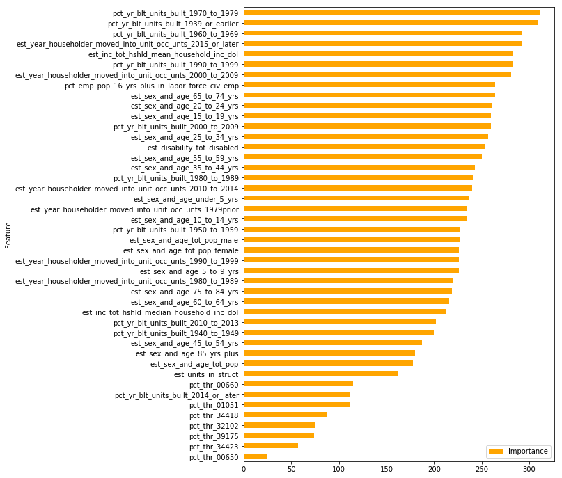

```python
importances = final_xgb.get_fscore()

importance_frame = pd.DataFrame({'Importance': list(importances.values()), 'Feature': list(importances.keys())})
importance_frame.sort_values(by = 'Importance', inplace = True)
importance_frame.plot(kind = 'barh', x = 'Feature', figsize = (8,12), color = 'orange')
```

### Set the cutoff and base_filename needed

```python
cutoff = 0.75
base_filename = '04-15-2018_SubsetFeatures-TestTrainVal-SMOTE-XGBoostRecallError-ParamOptCV'
```

### Save feature importance

```python
(pd.DataFrame.from_dict(data=importances, orient='index')
   .to_csv(base_filename + '_featimp.csv', header=False))
```

## Evaluate the final model using the validation data...

### Calculate prediction probabilities on the dval matrix

```python
y_pred = final_xgb.predict(dval)
y_pred
```

[output not shown]

[output cut: 37 more lines]

[output not shown]

### Calculate the AUC and optimal threshold

```
dval optimal_threshold: 	0.19
```

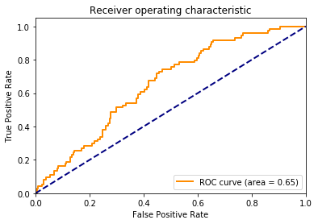

```python
# AUC - area under the ROC
fpr, tpr, thresholds = metrics.roc_curve(y_val.values, y_pred, pos_label=1)

optimal_idx = np.argmax(tpr - fpr)
optimal_threshold = thresholds[optimal_idx]
print("dval optimal_threshold: \t%.2f" % (optimal_threshold))

plt.figure()
lw = 2
plt.plot(fpr, tpr, color='darkorange', lw=lw,
        label='ROC curve (area = %0.2f)' % metrics.auc(fpr, tpr))
plt.plot([0, 1], [0, 1], color='navy', lw=lw, linestyle='--')
plt.xlim([0.0, 1.0])
plt.ylim([0.0, 1.05])
plt.xlabel('False Positive Rate')
plt.ylabel('True Positive Rate')
plt.title('Receiver operating characteristic')
plt.legend(loc="lower right")
plt.show()
```

### Convert probabilities back to the 0/1 label using the calculated cutoff

```python
y_pred[y_pred > optimal_threshold] = 1
y_pred[y_pred <= optimal_threshold] = 0
y_pred
```

[output not shown]

### Calculate accuracy, recall, confusion matrix, LIFT, and AUC for dval

```python
# accuracy
print("dval accuracy: \t%.2f%% with %.2f%% error rate and %.2f%% predict probability cutoff" % (accuracy_score(y_val, y_pred) * 100,
                                                                            (1-accuracy_score(y_val, y_pred)) * 100,
                                                                            optimal_threshold * 100))
# error
print("dval recall: \t%.2f%%" % (recall_score(y_val, y_pred) * 100))

# confusion matrix
tn, fp, fn, tp = confusion_matrix(y_val, y_pred).ravel()
print("confusion matrix: \n\ttn = %d\n\tfp = %d\n\tfn = %d\n\ttp = %d" % (tn, fp, fn, tp))

# LIFT - the ratio of correctly predicted positive examples and the actual positive examples
print("dval LIFT score: \t%.2f" % (lift_score(y_val, y_pred)))

# classification report
print('\nclasification report:\n', classification_report(y_val, y_pred))
```

```
dval accuracy: 	58.55% with 41.45% error rate and 18.86% predict probability cutoff
dval recall: 	72.97%
confusion matrix:
	tn = 107
	fp = 94
	fn = 20
	tp = 54
dval LIFT score: 	1.36

clasification report:
              precision    recall  f1-score   support

          0       0.84      0.53      0.65       201
          1       0.36      0.73      0.49        74

avg / total       0.71      0.59      0.61       275
```

## Evaluate the final model using the test data...

### Calculate prediction probabilities on the test matrix

```python
y_tpred = final_xgb.predict(dtest)
y_tpred
```

[output not shown]

[output cut: 82 more lines]

[output not shown]

### Calculate the AUC and optimal threshold

```
dtest optimal_threshold: 	0.01
```

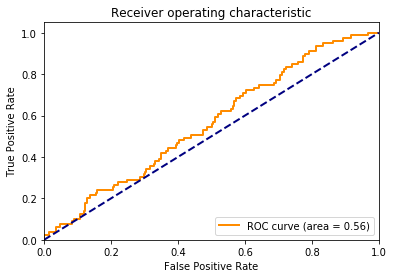

```python
# AUC - area under the ROC
fpr, tpr, thresholds = metrics.roc_curve(test_target.values, y_tpred, pos_label=1)

optimal_idx = np.argmax(tpr - fpr)
optimal_threshold = thresholds[optimal_idx]
print("dtest optimal_threshold: \t%.2f" % (optimal_threshold))

plt.figure()
lw = 2
plt.plot(fpr, tpr, color='darkorange', lw=lw,
        label='ROC curve (area = %0.2f)' % metrics.auc(fpr, tpr))
plt.plot([0, 1], [0, 1], color='navy', lw=lw, linestyle='--')
plt.xlim([0.0, 1.0])
plt.ylim([0.0, 1.05])
plt.xlabel('False Positive Rate')
plt.ylabel('True Positive Rate')
plt.title('Receiver operating characteristic')
plt.legend(loc="lower right")
plt.show()
```

### Convert probabilities back to the 0/1 label using the calculated cutoff

```python
y_tpred[y_tpred > optimal_threshold] = 1
y_tpred[y_tpred <= optimal_threshold] = 0
```

### Calculate accuracy, recall, confusion matrix, LIFT, and AUC for the test set

```python
# accuracy
print("dtest accuracy: \t%.2f%% with %.2f%% error rate and %.2f%% predict probability cutoff" % (accuracy_score(test_target, y_tpred) * 100,
                                                                             (1-accuracy_score(test_target, y_tpred)) * 100,
                                                                            optimal_threshold * 100))
# error
print("dtest recall: \t%.2f%%" % (recall_score(test_target, y_tpred) * 100))

# confusion matrix
tn, fp, fn, tp = confusion_matrix(test_target, y_tpred).ravel()
print("confusion matrix: \n\ttn = %d\n\tfp = %d\n\tfn = %d\n\ttp = %d" % (tn, fp, fn, tp))

# LIFT - the ratio of correctly predicted positive examples and the actual positive examples
print("dtest LIFT score: \t%.2f" % (lift_score(test_target, y_tpred)))

# AUC - area under the ROC
fpr, tpr, thresholds = metrics.roc_curve(test_target.values, y_tpred, pos_label=1)
print("dtest AUC score: \t%.2f" % (metrics.auc(fpr, tpr)))

# classification report
print('\nclasification report:\n', classification_report(test_target, y_tpred))
```

```
dtest accuracy: 	32.93% with 67.07% error rate and 0.57% predict probability cutoff
dtest recall: 	92.41%
confusion matrix:
	tn = 62
	fp = 269
	fn = 6
	tp = 73
dtest LIFT score: 	1.11
dtest AUC score: 	0.56

clasification report:
              precision    recall  f1-score   support

          0       0.91      0.19      0.31       331
          1       0.21      0.92      0.35        79

avg / total       0.78      0.33      0.32       410
```

## Save the model...

```python
# save the model to disk for reloading later
pickle.dump(final_xgb, open(base_filename + '_model.sav', 'wb'))
```

## Upload prediction results to AWS...

Previous code versions created a prediction result dataframe to ingesting into the AWS RDS Postgres database instance. This allowed the developers to track output versions and use the results with mapping and visualization services. The code for ingesting has been removed as the database instance will not be operational after project completion. Contact the repository point of contact if you have interest is obtaining the ingest code.

## References

- https://jessesw.com/XG-Boost/
- https://www.dataiku.com/learn/guide/code/python/advanced-xgboost-tuning.html
- https://machinelearningmastery.com/stochastic-gradient-boosting-xgboost-scikit-learn-python/
- http://contrib.scikit-learn.org/imbalanced-learn/stable/auto_examples/over-sampling/plot_random_over_sampling.html
- https://beckernick.github.io/oversampling-modeling/
- https://machinelearningmastery.com/save-load-machine-learning-models-python-scikit-learn/
- https://github.com/ipython-contrib/jupyter_contrib_nbextensions
- http://scikit-learn.org/stable/modules/model_evaluation.html#scoring-parameter
- https://www.rdocumentation.org/packages/xgboost/versions/0.6.4.1/topics/xgb.cv
- https://www.analyticsvidhya.com/blog/2016/03/complete-guide-parameter-tuning-xgboost-with-codes-python/
- http://xgboost.readthedocs.io/en/latest/how_to/param_tuning.html
- https://github.com/rpmcruz/machine-learning
- https://rasbt.github.io/mlxtend/
- https://machinelearningmastery.com/feature-importance-and-feature-selection-with-xgboost-in-python/